### Bivariate Normal Distribution

We will produce three bivariate normal distribution curves using R. It would be a good idea to try this program for various values of r between -1 and 1 to explore how the shape of the normal distribution varies with the correlation.

Download the Normal plot R file here: normplot.R

To simulate multivariate distributions we will create a function that calls other functions from the `MASS` package. Our function will require an argument for ρ, `rho`, which will be used to create a bivariate (2 x 2) correlation matrix. From the correlation matrix two new variables will be simulated using the `mvnorm()` function and their density distributions estimated and plotted with the `kde2d()` and `persp()` functions, respectively. Our function will also print the correlation coefficient for the two simulated variables.

We will start with two variables with ρ = 0.

```
## [1] -0.0007380988
```

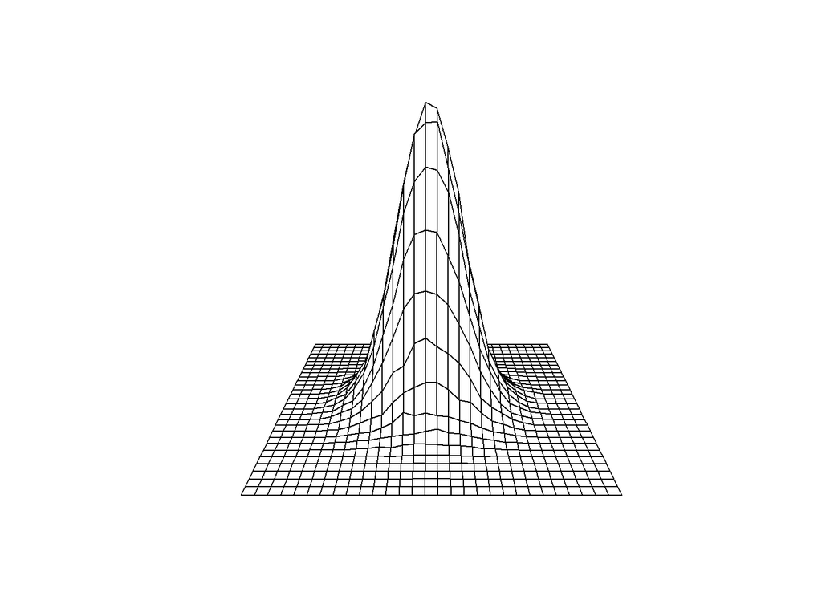

```r
library(MASS)

biv_dist <- function(rho) {
  rho <- rho

  Sigma <- rbind(c(1, rho),
                 c(rho, 1))

  set.seed(4960)
  xy <- as.data.frame(mvrnorm(1e5, c(1, 1), Sigma))

  den3d <- kde2d(xy$V1, xy$V2, n = 30)
  persp(den3d, box=FALSE)

  print(cor(xy$V1, xy$V2))
}

biv_dist(0)
```

The first plot shows the case where the correlation, ρ, is equal to zero. This special case is called the circular normal distribution. Here, we have a perfectly symmetric bell-shaped curve in three dimensions.

```r
biv_dist(0.7)
```

```
## [1] 0.7019047
```

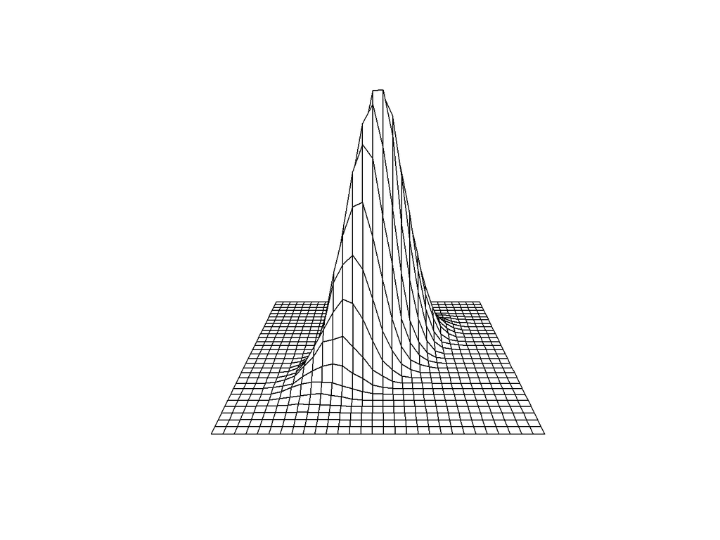

As ρ increases that bell-shaped curve becomes flattened on the 45-degree line. So for ρ equals 0.7 we can see that the curve extends out and becomes flattened in the perpendicular direction.

```r
biv_dist(0.9)
```

```
## [1] 0.9007091
```

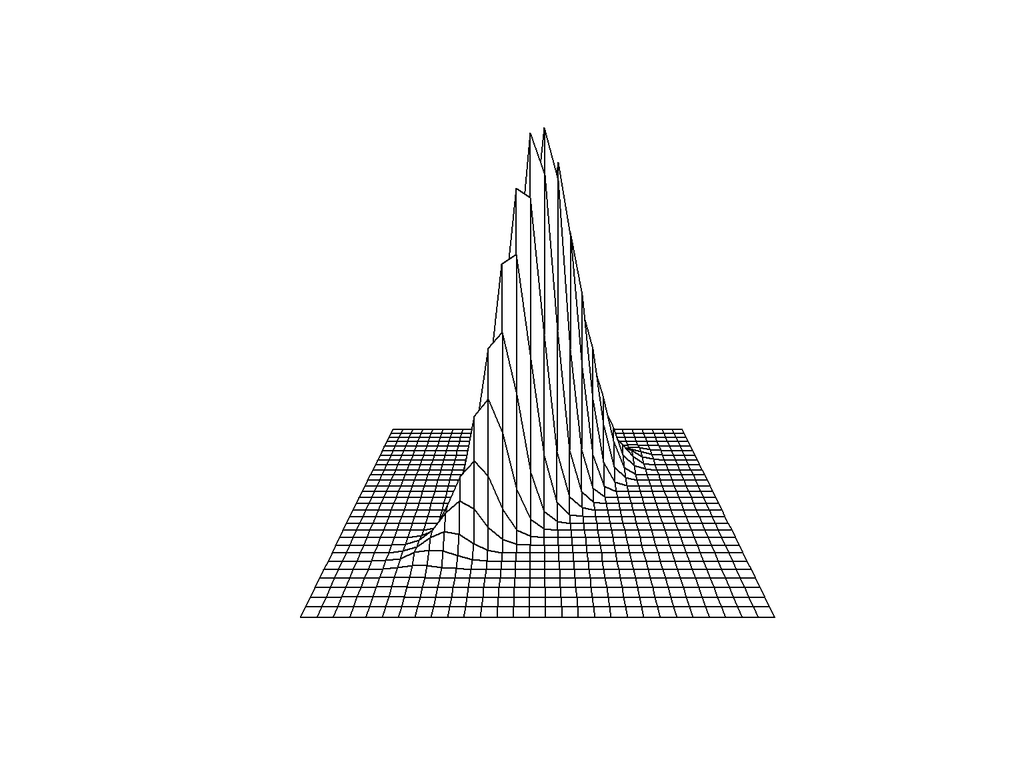

Increasing ρ to 0.9 the curve becomes broader and the 45-degree line and even flatter still in the perpendicular direction.